# Evolving Ideas and Narratives: Analyzing Raymond Moley’s Themes, Keywords, and Sentiment Over Time

Teona Goderdzishvili

December 08, 2024

**Research Questions**

**1.** How have Moley’s ideas and themes evolved over time?

**2.** How has the public perception of Moley, as reflected through descriptive language, changed throughout the years?

I aim to analyze how Moley’s most influential ideas developed and transformed across his work. Additionally, I want to understand how he was portrayed in contemporary papers and documents, focusing on the descriptive language and narratives used to characterize him. My methodological approach uses R for:

- Term frequency analysis to identify key concepts and recurring themes
- Keyword extraction to track specific ideas
- Sentiment analysis to evaluate the emotional tone of the texts
- Temporal trend visualization using ggplot to map changes in sentiment and themes over time

The research combines computational text analysis with historical context to provide insights into both Moley’s intellectual evolution and his public reception.

**Preliminary Work on Codebook**

**Economic Policy:** I’ll track the frequency and context of key terms related to Moley’s economic policy ideas, such as “new deal” and “reform”. This will help me understand the evolution of his policy positions over time.

**Ideological Stances:** I’ll analyze how Moley and his circle’s ideological stances, such as “liberalism” and “conservatism”, are portrayed in the articles. I’ll note if there are any significant changes or shifts in their positions over the years.

**Character Names and Descriptions:** The articles mention of some of the key names of the state actors. I will gather full names and brief descriptions of their roles and relationships with Moley.

**Character ID:** Give each character a unique 4-digit number, beginning with 0001. If a character appears in more than one episode, code him or her each time, but use the same ID number.

**Adjectives about Moley:** Moley became known as “the second strongest man in Washington”. They would also refer him as “Columbia university professor”, “Roosevelt’s brain trust”. I will explore how the adjectives related to Moley have been changing over the years.

Link to the source: https://github.com/wellsdata/CompText_Jour/tree/main/code/Moley_for_students/moley_newsweek/AI_extracted_all

#Appropriate software libraries

```r
library(tidyverse)
library(readtext)
library(kableExtra)
library(tidytext)
library(textdata)
library(pdftools)
library(stringr)
library(RCurl)
```

```r
library(ggplot2)
library(topicmodels)
```

```r
text_data <- read.csv("./moley_texts/moley_extracted_index.csv") %>%
  mutate(
    new_path = str_replace_all(new_path, "AI_extracted_all", "moley_texts"),
    date = ymd(date))
```

#Number of rows and columns of the dataset

```r
dim(text_data)
```

```
## [1] 110  12
```

```r
str(text_data)
```

```
## 'data.frame':    110 obs. of  12 variables:
##  $ X.1     : int  1 2 3 4 5 6 7 8 9 10 ...
##  $ X       : int  1 2 3 4 5 6 7 8 9 10 ...
##  $ column2 : chr  "Sowing the Windfallis" "Mr K, Farm Expert" "Lessons for Americans" "Dilemma of the Left" ...
##  $ list    : chr  "sim_newsweek-us_1959-07-06_54_1" "sim_newsweek-us_1959-09-28_54_13" "sim_newsweek-us_1959-10-26_54_17" "sim_newsweek-us_1959-11-30_54_22" ...
##  $ date    : Date, format: "1959-07-06" "1959-09-28" ...
##  $ Year    : int  1959 1959 1959 1959 1953 1953 1953 1955 1955 1957 ...
##  $ page    : int  89 125 133 113 113 109 113 65 125 121 ...
##  $ URL     : chr  "https://archive.org/details/sim_newsweek-us_1959-07-06_54_1/page/n89/mode/2up" "https://archive.org/details/sim_newsweek-us_1959-09-28_54_13/page/n125/mode/2up" "https://archive.org/details/sim_newsweek-us_1959-10-26_54_17/page/n133/mode/2up" "https://archive.org/details/sim_ne…
##  $ new_name: chr  "sim_newsweek-us_1959-07-06_54_1.txt" "sim_newsweek-us_1959-09-28_54_13.txt" "sim_newsweek-us_1959-10-26_54_17.txt" "sim_newsweek-us_1959-11-30_54_22.txt" ...
##  $ new_path: chr  "./moley_texts/sim_newsweek-us_1959-07-06_54_1.txt" "./moley_texts/sim_newsweek-us_1959-09-28_54_13.txt" "./moley_texts/sim_newsweek-us_1959-10-26_54_17.txt" "./moley_texts/sim_newsweek-us_1959-11-30_54_22.txt" ...
##  $ volume  : int  54 54 54 54 41 42 42 45 46 49 ...
##  $ issue   : int  1 13 17 22 4 13 22 1 22 18 ...
```

```r
summary(text_data)
```

```
##       X.1               X        column2              list
##  Min.   :  1.00   Min.   : 1   Length:110         Length:110
##  1st Qu.: 28.25   1st Qu.:14   Class :character   Class :character
##  Median : 55.50   Median :27   Mode  :character   Mode  :character
##  Mean   : 55.50   Mean   :27
##  3rd Qu.: 82.75   3rd Qu.:40
##  Max.   :110.00   Max.   :53
##                   NA's   :57
##       date                 Year           page           URL
##  Min.   :1942-09-28   Min.   :1942   Min.   : 35.0   Length:110
##  1st Qu.:1949-11-26   1st Qu.:1949   1st Qu.: 91.0   Class :character
##  Median :1954-12-06   Median :1954   Median :113.0   Mode  :character
##  Mean   :1954-04-11   Mean   :1954   Mean   :106.6
##  3rd Qu.:1958-07-12   3rd Qu.:1958   3rd Qu.:121.0
##  Max.   :1960-12-12   Max.   :1960   Max.   :133.0
##                                      NA's   :79
##    new_name           new_path             volume          issue
##  Length:110         Length:110         Min.   :20.00   Min.   : 1.00
##  Class :character   Class :character   1st Qu.:34.00   1st Qu.: 8.00
##  Mode  :character   Mode  :character   Median :44.50   Median :15.50
##                                        Mean   :43.03   Mean   :14.23
##                                        3rd Qu.:51.75   3rd Qu.:20.75
##                                        Max.   :56.00   Max.   :26.00
##
```

```r
nrow(text_data)
```

```
## [1] 110
```

```r
ncol(text_data)
```

```
## [1] 12
```

```r
cat("\nThe dataframe had", nrow(text_data) , "rows. \n" )
```

```
##
## The dataframe had 110 rows.
```

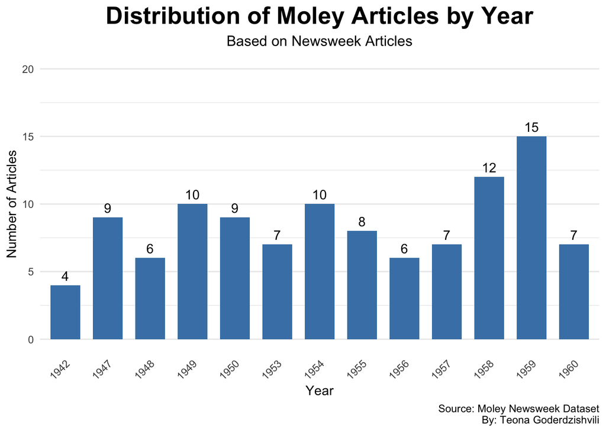

```r
# Combine both counts and sum up articles per year
yearly_counts <- text_data %>%
  count(Year)

# Create the visualization
ggplot(yearly_counts, aes(x = factor(Year), y = n)) +
  geom_bar(stat = "identity", fill = "steelblue", width = 0.7) +
  geom_text(aes(label = n), vjust = -0.5) +
  scale_y_continuous(limits=c(0,20)) +
  theme_minimal() +
  labs(
    title = "Distribution of Moley Articles by Year",
    subtitle = "Based on Newsweek Articles",
    x = "Year",
    y = "Number of Articles",
    caption = "Source: Moley Newsweek Dataset\nBy: Teona Goderdzishvili"
  ) +
  theme(
    plot.title = element_text(hjust = 0.5, size = 20, face = "bold"),
    plot.subtitle = element_text(hjust = 0.5, size = 12),
    axis.text.x = element_text(angle = 45, hjust = 1),
    panel.grid.major.x = element_blank(),
    panel.grid.minor.x = element_blank()
  )
```

```r
# Print the yearly counts
print("Yearly counts of all articles:")
```

```
## [1] "Yearly counts of all articles:"
```

```r
print(yearly_counts)
```

```
##    Year  n
## 1  1942  4
## 2  1947  9
## 3  1948  6
## 4  1949 10
## 5  1950  9
## 6  1953  7
## 7  1954 10
## 8  1955  8
## 9  1956  6
## 10 1957  7
## 11 1958 12
## 12 1959 15
## 13 1960  7
```

```r
# Save the plot
ggsave("moley_texts_per_year_combined.png", width = 12, height = 8, dpi = 300)
```

```r
folder_path <- "moley_texts"
txt_files <- list.files(folder_path, pattern = "\\.txt$", full.names = TRUE)

read_all_texts <- function(folder_path = "moley_texts") {
  if (!dir.exists(folder_path)) {
    stop("Folder '", folder_path, "' not found!")
  }

  txt_files <- list.files(
    path = folder_path,
    pattern = "\\.txt$",
    full.names = TRUE
  )

  if (length(txt_files) == 0) {
    stop("No .txt files found in folder '", folder_path, "'")
  }

  text_files <- readtext(txt_files) %>%
    as_tibble() %>%
    mutate(
      file_number = row_number(),
      doc_id = basename(doc_id),
      doc_id = str_remove(doc_id, "\\.txt$"),
      year = as.numeric(str_extract(doc_id, "\\d{4}"))
    )

  return(text_files)
}


text_files <- read_all_texts()

cat("Sample of the data:
")
```

```
## Sample of the data:
```

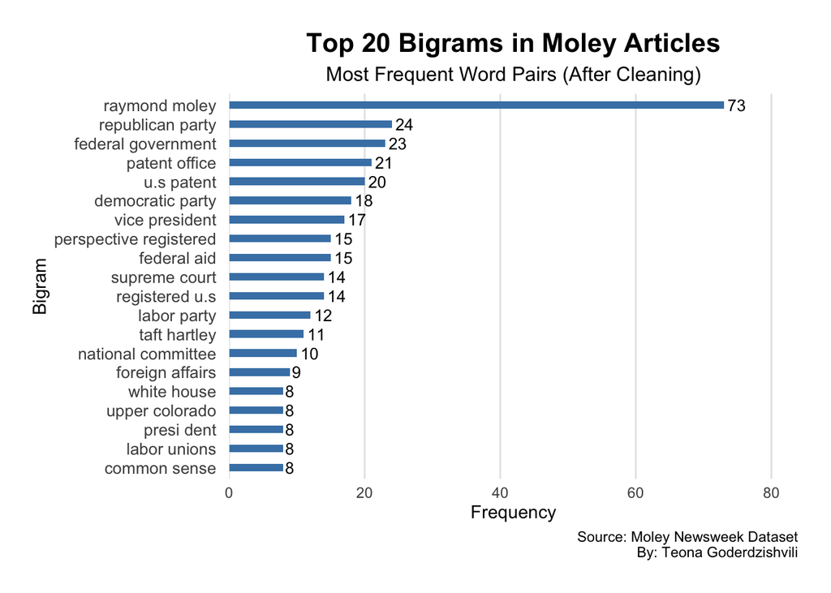

```r
# Create bigrams from the text
bigrams <- text_files %>%
  unnest_tokens(bigram, text, token = "ngrams", n = 2) %>%
  separate(bigram, c("word1", "word2"), sep = " ") %>%
  # Remove stop words
  filter(!word1 %in% stop_words$word,
         !word2 %in% stop_words$word,
         !is.na(word1),
         !is.na(word2)) %>%

  filter(!str_detect(word1, "^[0-9]+$"),
         !str_detect(word2, "^[0-9]+$")) %>%
  # Remove specific words you want to exclude
  filter(!word1 %in% c("mr", "mrs", "dr", "said", "says", "image", "years", "time", "week", "months", "page", "text", "article", "file", "files", "chapter", "note", "notes", "provided", "roll", "newsweek", "column", "congressional", "afl", "remain", "columns", "overlapping", "pdf", "avoid", "minor"),
         !word2 %in% c("mr", "mrs", "dr", "said", "says", "note", "years", "time", "week", "months", "page", "text", "article", "file", "files", "chapter", "note", "notes", "image", "calls", "september", "october", "layout", "quarterly", "cio", "due", "perspective", "columns", "formatted", "overlapping", "inoccurances")) %>%
  # Remove single-letter words and short words
  filter(str_length(word1) > 1,
         str_length(word2) > 1) %>%
  # Convert to lowercase to better group similar terms
  mutate(
    word1 = tolower(word1),
    word2 = tolower(word2)
  ) %>%
  count(word1, word2, sort = TRUE) %>%
  head(20)

# Create the plot with even more spacing
ggplot(bigrams, aes(x = reorder(paste(word1, word2), n), y = n)) +
  # Reduce bar width even more for more space
  geom_bar(stat = "identity", fill = "steelblue", width = 0.4) +
  geom_text(aes(label = n), hjust = -0.2, size = 3.5) +
  coord_flip() +
  theme_minimal() +
  labs(
    title = "Top 20 Bigrams in Moley Articles",
    subtitle = "Most Frequent Word Pairs (After Cleaning)",
    x = "Bigram",
    y = "Frequency",
    caption = "Source: Moley Newsweek Dataset\nBy: Teona Goderdzishvili"
  ) +
  theme(
    plot.title = element_text(hjust = 0.5, size = 16, face = "bold"),
    plot.subtitle = element_text(hjust = 0.5, size = 12),
    axis.text.y = element_text(size = 10, margin = margin(r = 5)),
    axis.text.x = element_text(size = 9),
    panel.grid.major.x = element_line(color = "gray90"),
    panel.grid.minor.x = element_blank(),
    panel.grid.major.y = element_blank(),
    plot.margin = margin(20, 20, 20, 20)
  ) +
  scale_y_continuous(expand = expansion(mult = c(0, 0.15)))
```

```r
# Save with increased height for even more spacing
ggsave("moley_top_bigrams_cleaned.png",
       width = 12,
       height = 40,  # Increased height significantly
       dpi = 300)
```

```r
text_data <- read_all_texts()

sentiment_summary <- text_data %>%
  unnest_tokens(word, text) %>%
  filter(!word %in% stop_words$word,
         !str_detect(word, "^[0-9]+$"),
         str_length(word) > 2) %>%
  filter(!word %in% c("mr", "mrs", "dr", "said", "says", "image",
                     "page", "text", "article", "file", "newsweek", "column",
                     "responsible", "win", "miracle", "grand", "true", "lost", "support","benefits")) %>%
  inner_join(get_sentiments("afinn"), by = "word") %>%
  group_by(word) %>%
  summarize(
    total_appearances = n(),
    sentiment_value = first(value),
    word_sentiment_total = total_appearances * sentiment_value
  ) %>%
  arrange(desc(abs(word_sentiment_total)))

print("Words sorted by sentiment impact (sentiment_value * appearances):")
```

```
## [1] "Words sorted by sentiment impact (sentiment_value * appearances):"
```

```r
print(head(sentiment_summary, 20))
```

```
## # A tibble: 20 × 4
##    word       total_appearances sentiment_value word_sentiment_total
##    <chr>                  <int>           <dbl>                <dbl>
##  1 war                       72              -2                 -144
##  2 strong                    23               2                   46
##  3 united                    42               1                   42
##  4 won                       14               3                   42
##  5 crisis                    13              -3                  -39
##  6 wealth                    13               3                   39
##  7 strength                  18               2                   36
##  8 freedom                   17               2                   34
##  9 hope                      17               2                   34
## 10 justice                   16               2                   32
## 11 popular                   10               3                   30
## 12 importance                14               2                   28
## 13 rich                      14               2                   28
## 14 bad                        9              -3                  -27
## 15 bitter                    13              -2                  -26
## 16 burden                    13              -2                  -26
## 17 confidence                13               2                   26
## 18 fair                      13               2                   26
## 19 growth                    13               2                   26
## 20 poor                      13              -2                  -26
```

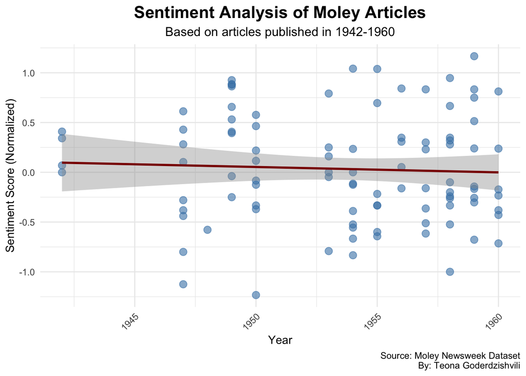

```r
# Create sentiment analysis by article
article_sentiment <- text_data %>%
  unnest_tokens(word, text) %>%
  filter(!word %in% stop_words$word,
         !str_detect(word, "^[0-9]+$"),
         str_length(word) > 2) %>%
  filter(!word %in% c("mr", "mrs", "dr", "said", "says", "image",
                     "page", "text", "article", "file", "newsweek", "column",
                     "responsible", "win", "miracle", "grand", "true", "lost")) %>%
  inner_join(get_sentiments("afinn"), by = "word", "support") %>%
  group_by(doc_id, year) %>%
  summarize(
    sentiment_score = sum(value),
    words = n(),
    .groups = "drop"
  ) %>%
  filter(!is.na(year)) %>%
  mutate(normalized_sentiment = sentiment_score/words)

# Create visualization
ggplot(article_sentiment, aes(x = year, y = normalized_sentiment)) +
  geom_point(alpha = 0.6, color = "steelblue", size = 3) +
  geom_smooth(formula = y ~ x, method = "lm", color = "darkred") +
  theme_minimal() +
  labs(
    title = "Sentiment Analysis of Moley Articles",
    subtitle = "Based on articles published in 1942-1960",
    x = "Year",
    y = "Sentiment Score (Normalized)",
    caption = "Source: Moley Newsweek Dataset\nBy: Teona Goderdzishvili"
  ) +
  theme(
    plot.title = element_text(hjust = 0.5, size = 16, face = "bold"),
    plot.subtitle = element_text(hjust = 0.5, size = 12),  # Added this line to center subtitle
    axis.text.x = element_text(angle = 45, hjust = 1)
  )
```

```r
ggsave("moley_sentiment_analysis.png", width = 12, height = 8, dpi = 300)
```

#Topic modeling

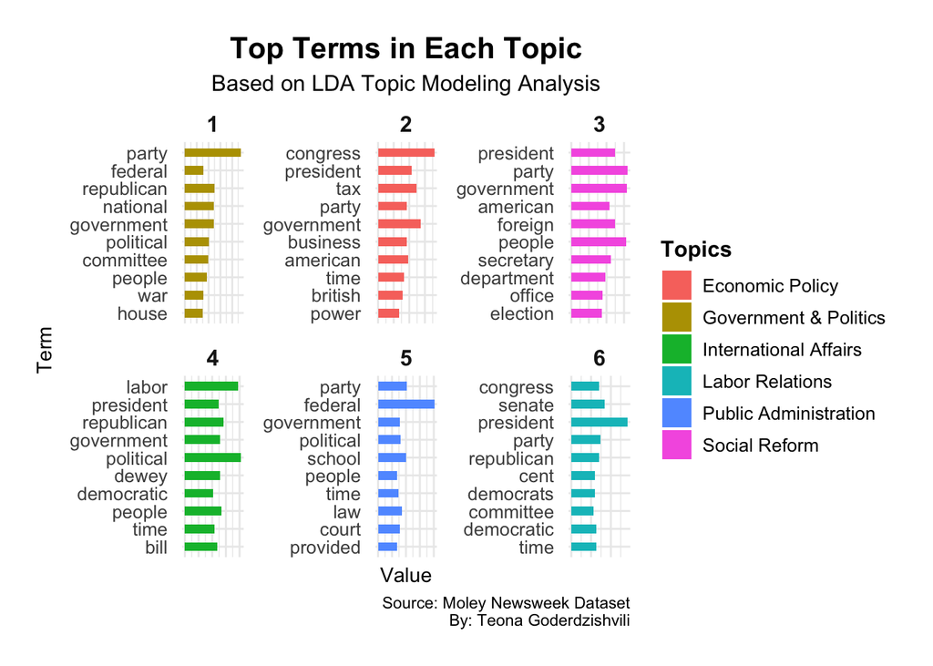

```r
# 1. Create Document-Term Matrix (DTM) and LDA model
dtm <- text_data %>%
  unnest_tokens(word, text) %>%
  filter(!word %in% stop_words$word,
         !str_detect(word, "^[0-9]+$"),
         str_length(word) > 2) %>%
  filter(!word %in% c("mr", "mrs", "dr", "said", "says", "image",
                     "page", "text", "article", "file", "newsweek", "column")) %>%
  count(doc_id, word) %>%
  cast_dtm(doc_id, word, n)

lda_model <- LDA(dtm, k = 6, control = list(seed = 1234))

# Define custom topic labels
topic_labels <- c(
  "1" = "Government & Politics",
  "2" = "Economic Policy",
  "3" = "Social Reform",
  "4" = "International Affairs",
  "5" = "Public Administration",
  "6" = "Labor Relations"
)

# Extract top terms from topics
top_terms <- tidy(lda_model, matrix = "beta") %>%
  group_by(topic) %>%
  slice_max(beta, n = 10) %>%
  arrange(topic, -beta) %>%
  mutate(topic_label = recode(as.character(topic), !!!topic_labels))  # Add topic labels

# Visualization with "Value" label and hidden numerical y-axis values
ggplot(top_terms, aes(reorder(term, beta), beta, fill = topic_label)) +
  geom_col(width = 0.5) +
  facet_wrap(~topic, scales = "free") +
  coord_flip() +
  labs(
    title = "Top Terms in Each Topic",
    subtitle = "Based on LDA Topic Modeling Analysis",
    x = "Term",
    y = "Value",  # Retain "Value" on the y-axis
    fill = "Topics",  # Legend for topics
    caption = "Source: Moley Newsweek Dataset\nBy: Teona Goderdzishvili"
  ) +
  scale_y_continuous(labels = NULL) +  # Remove numerical labels on y-axis
  theme_minimal() +
  theme(
    plot.title = element_text(hjust = 0.5, size = 16, face = "bold"),
    plot.subtitle = element_text(hjust = 0.5, size = 12),
    axis.text.y = element_text(size = 10, margin = margin(r = 5, l = 5)),
    strip.text = element_text(size = 12, face = "bold"),  # Keep original column titles
    legend.position = "right",  # Add legend to the right
    legend.title = element_text(size = 12, face = "bold"),
    legend.text = element_text(size = 10),
    plot.margin = margin(t = 20, r = 20, b = 20, l = 20)  # Add margin around the plot
  )
```

```r
# Save the updated plot
ggsave(
  "moley_topics_analysis_value_no_numbers.png",
  width = 12,
  height = 15,
  dpi = 300
)
```